# Lecture 14: Multiple events and event history modelling

STA310 Survival Analysis · Collett Chapter 13

2026-10-06

## Today

1. Recurrent events: why and how?
2. Counting-process data layout
3. Andersen-Gill (AG) model
4. PWP and WLW models; which to choose?
5. Mean cumulative function
6. Terminal events, frailty (pointer)
7. Multi-state models and event history
8. Exercise, take-home

**Learning goals**

After today you can

- set up recurrent event data in start-stop format
- fit and interpret AG and PWP models with robust standard errors
- choose a model from the research question
- plot a mean cumulative function
- explain why death in a recurrent-event setting is a competing risk

# Why multiple events?

## Many diseases do not “happen once”

| Setting | Repeated event |
| --- | --- |
| Chronic granulomatous disease | Serious infections |
| Bladder cancer | Tumour recurrences |
| Heart failure, COPD | Hospitalisations |
| Epilepsy | Seizures |
| Animal carcinogenesis | Mammary tumours |

So far each subject contributed **at most one** event. Now a subject can have $0, 1, 2, \dots$ events, and the same subject appears repeatedly in the data.

## Two naive approaches, both flawed

**1. Time to first event only (ordinary Cox)**

- Valid, simple
- But throws away all information after the first event
- Answers only “does treatment delay the *first* event?”

**2. Treat every event as an independent subject**

- Uses all the data
- But events within the same patient are **correlated** (some patients are simply more prone)
- Model-based standard errors are then wrong, usually too small

**Important**

Goal: use **all events** and get **valid standard errors** under within-subject dependence.

## Example 1: chronic granulomatous disease (CGD)

Randomised trial of interferon gamma (rIFN-g) vs placebo to prevent serious infections in patients with CGD (the data set `cgd` from the `survival` package, `survival::cgd`). One row per **at-risk interval**. Column names of counting-process data vary between packages and data sets (`start`/`stop` here in `bladder2`, `tstart`/`tstop` in `cgd`), as noted in Lecture 10.

```r
cgd |> select(id, treat, tstart, tstop, status, enum) |> head(10)
```

```
   id   treat tstart tstop status enum
1   1  rIFN-g      0   219      1    1
2   1  rIFN-g    219   373      1    2
3   1  rIFN-g    373   414      0    3
4   2 placebo      0     8      1    1
5   2 placebo      8    26      1    2
6   2 placebo     26   152      1    3
7   2 placebo    152   241      1    4
8   2 placebo    241   249      1    5
9   2 placebo    249   322      1    6
10  2 placebo    322   350      1    7
```

```r
cgd |> count(id) |> summarise(patients = n(), events = sum(cgd$status), max_rows = max(n))
```

```
  patients events max_rows
1      128     76        8
```

Patient 1 had infections at days 219 and 373 and was censored at day 414; patient 2 had 7 infections (the last at day 350) and was censored at day 439.

## Example 2: bladder cancer

Trial of thiotepa vs placebo after transurethral resection of superficial bladder tumours (`survival::bladder2`; 85 patients, rows are at-risk intervals for up to 4 recurrences, times in months).

```r
bladder2 |> select(id, rx, number, size, start, stop, event, enum) |> head(8)
```

```
  id rx number size start stop event enum
1  1  1      1    3     0    1     0    1
2  2  1      2    1     0    4     0    1
3  3  1      1    1     0    7     0    1
4  4  1      5    1     0   10     0    1
5  5  1      4    1     0    6     1    1
6  5  1      4    1     6   10     0    2
7  6  1      1    1     0   14     0    1
8  7  1      1    1     0   18     0    1
```

Patient 5 had a recurrence at month 6 and was censored at month 10. Here `rx` is 1 = placebo, 2 = thiotepa, `number` = initial number of tumours, `size` = size of the largest.

## Example 3: mammary tumours in rats (Collett Example 13.2)

48 rats randomised to retinoid prophylaxis or control, followed 122 days; times to each tumour.

```r
rats |> filter(rat == 5)
```

```
  rat treatment time status
1   5  Retinoid   70      1
2   5  Retinoid   74      1
3   5  Retinoid   85      1
4   5  Retinoid   92      1
5   5  Retinoid  122      0
```

```r
rats |> summarise(rats = n_distinct(rat), tumours = sum(status), .by = treatment)
```

```
  treatment rats tumours
1  Retinoid   23      61
2   Control   25     151
```

Time is **time since randomisation** (calendar time): rat 5 had tumours at days 70, 74, 85, 92 and was censored at 122.

# The counting-process formulation

## Counting process and intensity

For subject $i$, let $N_i(t)$ = number of events up to time $t$, and $Y_i(t) \in \{0,1\}$ = 1 while the subject is under observation.

The **intensity** is the hazard of the next event given the history (Collett’s $\lambda$); we keep the symbol $h_i(t)$:

$$h_i(t) = \lim_{\delta \to 0} \frac{P\{\text{event in } [t, t+\delta) \mid \text{history up to } t\}}{\delta}.$$

Models take the form $h_i(t) = Y_i(t)\, h_0(t) \exp(\beta' x_i)$, and the partial likelihood is the Cox one, with each *interval* contributing to the risk sets while it is at risk.

## Data layout: one row per at-risk interval

Subject with events at times $t_1 < t_2$ and censored at $c$:

| id | start | stop | event | enum |
| --- | --- | --- | --- | --- |
| 1 | 0 | $t_1$ | 1 | 1 |
| 1 | $t_1$ | $t_2$ | 1 | 2 |
| 1 | $t_2$ | $c$ | 0 | 3 |

- `Surv(start, stop, event)`: introduced in lecture 10 for time-dependent covariates
- Intervals do not overlap; a subject is at risk only in the interval where the row applies
- The last row ends with censoring (status 0) when follow-up continues after the last event

## Building the layout from raw data: the rats

The rats file has one row per tumour, with total times. We create `start` as the previous stop within a rat.

```r
rats_cp <- rats |>
  group_by(rat) |>
  mutate(start = lag(time, default = 0), enum = row_number()) |>
  ungroup()
rats_cp |> filter(rat %in% c(3, 5)) |> select(rat, treatment, start, stop = time, status, enum)
```

```
# A tibble: 8 × 6
    rat treatment start  stop status  enum
  <int> <fct>     <dbl> <dbl>  <int> <int>
1     3 Retinoid      0     3      1     1
2     3 Retinoid      3     8      1     2
3     3 Retinoid      8   122      0     3
4     5 Retinoid      0    70      1     1
5     5 Retinoid     70    74      1     2
6     5 Retinoid     74    85      1     3
7     5 Retinoid     85    92      1     4
8     5 Retinoid     92   122      0     5
```

**Note**

In this file a few tumours at the same assessment have been separated by adding $0.1$ to ties (Collett), so that start < stop always. Check `all(rats_cp$time > rats_cp$start)`: TRUE.

## Calendar (total) time vs gap time

**Total (calendar) time**

- Clock runs from the origin (randomisation) and is **not reset**
- Row: `Surv(start, stop, event)`
- Question: what is the event rate at time $t$ since randomisation?

**Gap time**

- Clock **resets to 0** after each event
- Row: `Surv(stop - start, event)`
- Question: how long to the next event after the previous one?

Both use the same data; only the time scale of the baseline hazard differs. With gap time the risk sets contain only patients at the same time *since their last event*.

```r
cgd |> mutate(gap = tstop - tstart) |> select(id, tstart, tstop, gap, status, enum) |> head(5)
```

```
  id tstart tstop gap status enum
1  1      0   219 219      1    1
2  1    219   373 154      1    2
3  1    373   414  41      0    3
4  2      0     8   8      1    1
5  2      8    26  18      1    2
```

# Models for recurrent events

## Overview of the three classical models

| Model | Baseline hazard | Risk set for event $k$ | Time scale |
| --- | --- | --- | --- |
| **AG** (Andersen-Gill) | common to all events | everyone under observation | total time |
| **PWP** (Prentice, Williams, Peterson) | stratum-specific $h_{0k}(t)$ | only those who have had $k-1$ events | total or gap time |
| **WLW** (Wei, Lin, Weissfeld) | stratum-specific, marginal | everyone is at risk for every event from time 0 | total time |

All are fitted with `coxph()` and need **robust** variance (`cluster(id)`) because events within a subject are correlated.

## Step 1: ordinary Cox on time to first event

```r
first <- cgd |> filter(enum == 1)
fit_first <- coxph(Surv(tstop, status) ~ treat, data = first)
broom::tidy(fit_first, exponentiate = TRUE, conf.int = TRUE) |> select(term, estimate, std.error, conf.low, conf.high, p.value)
```

```
# A tibble: 1 × 6
  term        estimate std.error conf.low conf.high p.value
  <chr>          <dbl>     <dbl>    <dbl>     <dbl>   <dbl>
1 treatrIFN-g    0.335     0.335    0.174     0.645 0.00108
```

Time to first infection: hazard ratio 0.33 for rIFN-g vs placebo, using 128 patients and 44 events. Of the 76 infections in the trial, only these are used.

## The Andersen-Gill model

$$h_i(t) = Y_i(t)\, h_0(t) \exp(\beta' x_i)$$

- **One** baseline hazard $h_0(t)$, identical for all events of all subjects
- After adjusting for covariates, events are **conditionally independent** (the number of earlier events does not affect later hazards)
- $\exp(\beta)$ = ratio of event **rates** (intensities) at any time
- Fitted by Cox regression on the counting-process data; use **robust sandwich variance**, since conditional independence rarely holds exactly

## AG in R: CGD

```r
fit_ag_naive <- coxph(Surv(tstart, tstop, status) ~ treat, data = cgd)
fit_ag <- coxph(Surv(tstart, tstop, status) ~ treat + cluster(id), data = cgd)
fit_ag
```

```
Call:
coxph(formula = Surv(tstart, tstop, status) ~ treat, data = cgd,
    cluster = id)

               coef exp(coef) se(coef) robust se      z        p
treatrIFN-g -1.0953    0.3344   0.2610    0.3119 -3.511 0.000446

Likelihood ratio test=20.11  on 1 df, p=7.32e-06
n= 203, number of events= 76
```

`cluster(id)` switches the reported SE to the robust one (column `robust se`); the model-based `se(coef)` is kept for comparison.

## AG: interpretation

The AG rate ratio for rIFN-g vs placebo is 0.33 (95% CI 0.18 to 0.62).

- Interferon gamma is associated with a roughly 67% lower rate of serious infections at any time, averaged over all infection episodes
- Robust SE 0.312 vs naive SE 0.261. Here the robust SE is larger, as is typical when events cluster within patients
- Time to first infection gives a similar HR (0.33), but with 44 instead of 76 events

**Warning**

The estimate averages over episodes. It does not say whether the effect is the same for the 1st and the 3rd infection.

## The PWP model

Conditional on having had $k-1$ events, stratify by event number $k$:

$$h_{ik}(t) = Y_{ik}(t)\, h_{0k}(t) \exp(\beta' x_i)$$

- A subject is at risk for event $k$ only after event $k-1$ has occurred: **ordered** events
- **Stratified** baseline: the hazard may differ for event 1, 2, 3, …
- $\beta$ common across strata (or interact with stratum to get event-specific effects)
- Two time scales: **total time** (`Surv(start, stop, ...)`) or **gap time** (`Surv(stop - start, ...)`)
- Sparse high event numbers: pool the last strata (here events $\ge 4$ form stratum 4)

## PWP in R: CGD

```r
fit_pwp_tt <- coxph(Surv(tstart, tstop, status) ~ treat + strata(enum4) + cluster(id), data = cgd)
fit_pwp_gt <- coxph(Surv(tstop - tstart, status) ~ treat + strata(enum4) + cluster(id), data = cgd)
```

```r
bind_rows(
  `PWP total time` = broom::tidy(fit_pwp_tt, exponentiate = TRUE, conf.int = TRUE),
  `PWP gap time`   = broom::tidy(fit_pwp_gt, exponentiate = TRUE, conf.int = TRUE),
  .id = "model") |>
  select(model, HR = estimate, `robust SE (log)` = robust.se, conf.low, conf.high) |>
  mutate(across(where(is.numeric), \(x) round(x, 3)))
```

```
# A tibble: 2 × 5
  model             HR `robust SE (log)` conf.low conf.high
  <chr>          <dbl>             <dbl>    <dbl>     <dbl>
1 PWP total time 0.417             0.286    0.238     0.731
2 PWP gap time   0.415             0.279    0.24      0.718
```

## Comparing the approaches: CGD

```r
get <- function(f, label) {
  s <- summary(f)$coefficients
  tibble(model = label, HR = exp(s[1, "coef"]),
         se_naive = s[1, "se(coef)"],
         se_robust = if ("robust se" %in% colnames(s)) s[1, "robust se"] else NA,
         lower = exp(confint(f)[1]), upper = exp(confint(f)[2]))
}
bind_rows(get(fit_first, "First event only"),
          get(fit_ag_naive, "AG, naive SE"),
          get(fit_ag, "AG, robust SE"),
          get(fit_pwp_tt, "PWP total time"),
          get(fit_pwp_gt, "PWP gap time")) |>
  mutate(across(where(is.numeric), \(x) round(x, 3))) |> knitr::kable()
```

| model | HR | se_naive | se_robust | lower | upper |
| --- | --- | --- | --- | --- | --- |
| First event only | 0.335 | 0.335 | NA | 0.174 | 0.645 |
| AG, naive SE | 0.334 | 0.261 | NA | 0.201 | 0.558 |
| AG, robust SE | 0.334 | 0.261 | 0.312 | 0.181 | 0.616 |
| PWP total time | 0.417 | 0.279 | 0.286 | 0.238 | 0.731 |
| PWP gap time | 0.415 | 0.278 | 0.279 | 0.240 | 0.718 |

## CGD: what do we learn?

- All models point to a **lower infection hazard on rIFN-g** (HRs from 0.33 to 0.42)
- The AG estimate is farther from 1 than PWP. A possible reason: PWP compares patients with the same number of earlier infections, so part of the treatment effect that works through earlier infections is removed. Differences are small relative to the CIs
- Using recurrent events (AG) increases the number of events and gives a narrower CI than first event only
- Robust vs naive SE: always report the robust one

**Note**

Different models estimate **different quantities**. They are not expected to agree exactly.

## Bladder cancer: the same workflow

```r
fit_b_first <- coxph(Surv(stop, event) ~ trt + number + size, data = filter(bladder2, enum == 1))
fit_b_ag    <- coxph(Surv(start, stop, event) ~ trt + number + size + cluster(id), data = bladder2)
fit_b_pwp   <- coxph(Surv(start, stop, event) ~ trt + number + size + strata(enum4) + cluster(id), data = bladder2)
fit_b_pwpg  <- coxph(Surv(stop - start, event) ~ trt + number + size + strata(enum4) + cluster(id), data = bladder2)
```

```r
list(`First event` = fit_b_first, AG = fit_b_ag, `PWP total` = fit_b_pwp, `PWP gap` = fit_b_pwpg) |>
  map_dfr(\(f) broom::tidy(f, exponentiate = TRUE, conf.int = TRUE) |> filter(term == "trtThiotepa"), .id = "model") |>
  select(model, HR = estimate, conf.low, conf.high, p.value) |>
  mutate(across(where(is.numeric), \(x) round(x, 3))) |> knitr::kable()
```

| model | HR | conf.low | conf.high | p.value |
| --- | --- | --- | --- | --- |
| First event | 0.591 | 0.318 | 1.097 | 0.096 |
| AG | 0.628 | 0.373 | 1.057 | 0.080 |
| PWP total | 0.716 | 0.480 | 1.070 | 0.103 |
| PWP gap | 0.757 | 0.496 | 1.154 | 0.196 |

## Bladder cancer: interpretation

The `bladder2` data have 112 recurrences in 85 patients (at most 4 per patient are recorded).

- Thiotepa vs placebo, AG: rate ratio 0.63; first event only: 0.59
- The 95% CIs of all four models include 1 (see table): weak evidence of a benefit, and the point estimates attenuate from AG to PWP gap time
- Initial number of tumours (`number`): HR 1.19 per additional tumour (AG)

**Warning**

Small trial (85 patients): CIs are wide, and conclusions differ in their *interpretation* by model, not just numerically.

## The book’s first-recurrence bladder data

The first-recurrence version of the bladder data in the book’s data sets (86 rows; `init` = initial number of tumours). `treat` is coded 1/2; the book chapter does not state which code is the active treatment, so we do not label it (here `treat` 1/2 presumably corresponds to `rx` above, but this is not verified).

```r
head(bladder_first, 4)
```

```
  patient time status treat init size
1       1    0      0     1    1    1
2       2    1      0     1    1    3
3       3    4      0     1    2    1
4       4    7      0     1    1    1
```

```r
coxph(Surv(time, status) ~ factor(treat) + size, data = bladder_first) |>
  broom::tidy(exponentiate = TRUE) |>
  mutate(term = recode(term, `factor(treat)2` = "treat 2 vs treat 1", size = "size (per unit)"))
```

```
# A tibble: 2 × 5
  term               estimate std.error statistic p.value
  <chr>                 <dbl>     <dbl>     <dbl>   <dbl>
1 treat 2 vs treat 1    0.692     0.303    -1.21    0.225
2 size (per unit)       1.03      0.100     0.266   0.790
```

This is exactly the “wasteful” analysis: the recurrence-by-recurrence data above contain more events.

## The WLW marginal model (briefly)

For each event number $k$ fit a separate Cox model for “time to event $k$”, **as if every subject were at risk for all $K$ events from time 0**:

$$h_{ik}(t) = h_{0k}(t)\exp(\beta_k' x_i)$$

- Each stratum uses total time from the origin; sandwich variance accounts for correlation across $k$
- Gives event-specific effects $\beta_k$, optionally averaged into one common $\beta$
- Needs a good number of events at every $k$
- Criticism: subjects are “at risk” for event 3 before they have had event 2, which is hard to interpret
- Today’s focus is AG and PWP, WLW is shown for completeness

## Choosing among the models

| Research question | Suitable model |
| --- | --- |
| Does treatment reduce the **overall rate** of events? | AG (robust SE) |
| Does treatment affect the **time to the $k$-th event, given that $k-1$ have occurred**? | PWP, stratified by event number |
| Is the time **between** events (recovery period) affected? | PWP gap time |
| Is the effect the same for the 1st, 2nd, 3rd event? | PWP/WLW with event-specific $\beta_k$ |
| Events are not ordered (different types, e.g. both eyes)? | WLW marginal model |
| Only the first event matters (e.g. death, stroke)? | Ordinary Cox |

## Assumptions and pitfalls

- AG: conditional independence given covariates, and no dependence on number of previous events. Violations bias SEs unless robust variance is used. Add covariates such as the *number of previous events* when plausible
- PWP: conditional effects can suffer **selection bias**: patients reaching event 3 are a selected subgroup
- Independent (non-informative) censoring, as always
- Robust SEs rely on a reasonable number of subjects (clusters), not events
- Do not just pick the model with the smallest p-value

# Mean cumulative function

## Mean cumulative function (MCF)

The MCF is the expected number of events per subject up to time $t$:

$$M(t) = E\{N(t)\}$$

- Estimated by a Nelson-Aalen type estimator: $\hat M(t) = \sum_{t_j \le t} d_j / n_j$, where $n_j$ is the number of subjects at risk at $t_j$
- Plot per treatment group: slope = event rate, and you can read “events by time $t$”
- In R: `survfit()` with counting-process data and `id`

## MCF in R: CGD

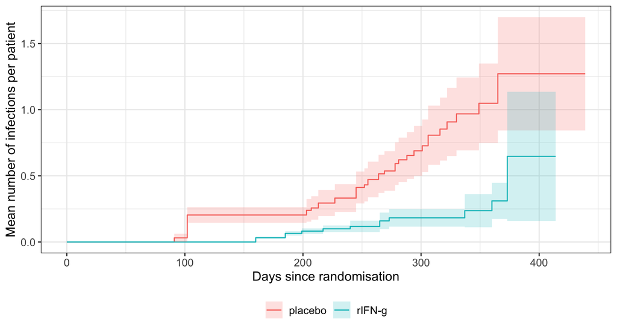

```r
survfit2(Surv(tstart, tstop, status) ~ treat, id = id, data = cgd) |>
  ggsurvfit(type = "cumhaz") +
  add_confidence_interval() +
  labs(x = "Days since randomisation", y = "Mean number of infections per patient")
```

Note: `id =` is needed so that a patient’s several rows are one subject. Without it, rows would be counted as separate subjects.

## MCF: interpretation

```r
mcf <- survfit(Surv(tstart, tstop, status) ~ treat, id = id, data = cgd)
s <- summary(mcf, times = 300)
```

At 300 days the estimated mean number of infections per patient is 0.66 in the placebo group and 0.18 in the rIFN-g group (this is $\hat M(t)$, not a probability and can exceed 1).

**Note**

Compare with the first-event KM curve: the MCF counts *all* infections, KM only the first. If patients are lost to death the MCF can be biased, see later.

## MCF in R: rats and bladder

[figure not shown]

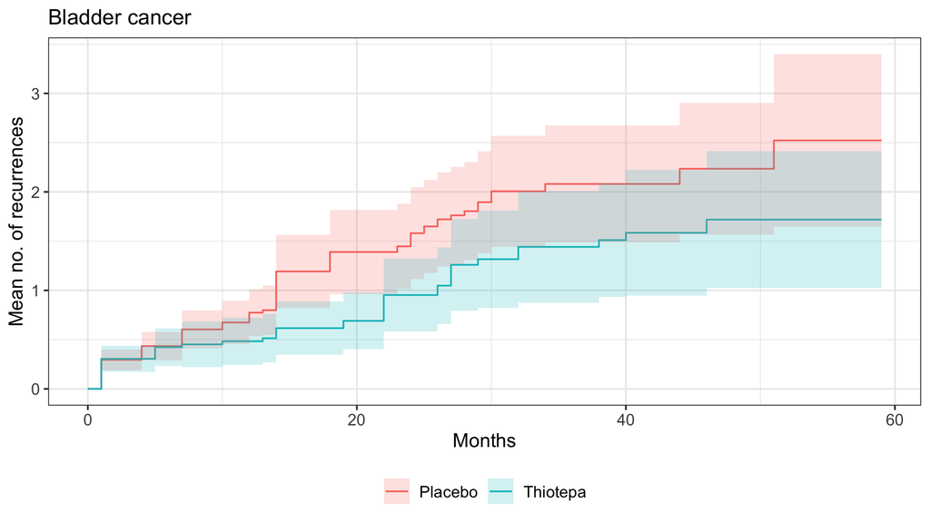

```r
survfit2(Surv(start, time, status) ~ treatment, id = rat, data = rats_cp) |>
  ggsurvfit(type = "cumhaz") + add_confidence_interval() +
  labs(x = "Days since randomisation", y = "Mean no. of tumours", title = "Rats")
survfit2(Surv(start, stop, event) ~ trt, id = id, data = bladder2) |>
  ggsurvfit(type = "cumhaz") + add_confidence_interval() +
  labs(x = "Months", y = "Mean no. of recurrences", title = "Bladder cancer")
```

## Rats: AG model (Collett Example 13.2)

```r
fit_rat <- coxph(Surv(start, time, status) ~ treatment + cluster(rat), data = rats_cp)
summary(fit_rat)$coefficients
```

```
                        coef exp(coef)  se(coef) robust se         z
treatmentRetinoid -0.8492381 0.4277407 0.1519767 0.2108253 -4.028159
                      Pr(>|z|)
treatmentRetinoid 5.621527e-05
```

Rate ratio for retinoid vs control 0.43 (95% CI 0.28 to 0.65, robust SE 0.211). Collett reports 0.45 (0.30, 0.66) with robust SE 0.198.

The supplied file has 254 rows for 48 rats (23 retinoid, 25 control). We compared it with Table 13.2 of the book: all rats, times and censoring indicators agree, so the data are not the cause. The default `coxph` tie handling is Efron; with `ties = "breslow"` we get rate ratio 0.44 and robust SE 0.198, i.e. the book’s robust SE (0.198) and a rate ratio near its 0.45. The book does not state its tie method (many ties here), so the remaining difference is unexplained. First-event-only HR: 0.48 (Efron), Collett 0.50.

# Terminal events and frailty

## Death stops the recurrences

Patients may die, and after death **no more events can occur**.

- Death is a **competing risk** for further recurrences (lecture 13) and, in contrast to ordinary censoring, is *informative*: sick patients both recur more and die earlier
- Treating death as censoring in AG/PWP/MCF answers a hypothetical question (rate “if nobody died”) and can mislead
- Practical options: report the **terminal event** separately with Cox, or analyse a composite (recurrence or death)
- Joint models of recurrent and terminal events exist (joint frailty models), as does the `mstate` package. We only name them here

**Warning**

A treatment that reduces hospitalisations because patients die sooner is not an improvement.

## Frailty: pointer to Lecture 15

An alternative to robust SEs is to add a subject-level random effect (frailty) $z_i$ with $E(z_i) = 1$ and $\text{Var}(z_i) = \theta$:

$$h_i(t) = z_i\, h_0(t)\exp(\beta' x_i)$$

This gives a conditional (subject-specific) interpretation, in contrast to the marginal AG/PWP approach of today. The theory, `frailty()` in R and the conditional vs marginal contrast are in **Lecture 15**.

# Multi-state models and event history

## Event history language

A subject moves between **states**; an **event** is a **transition**; the hazard of each transition is the **transition intensity**.

- Recurrent events: states “0 events”, “1 event”, “2 events”, … (PWP is a multi-state model)
- Competing risks: one start state, several absorbing states
- Illness-death: the classical example

```
flowchart LR
  A[Healthy] -->|"h01(t)"| B[Illness]
  A -->|"h02(t)"| C[Death]
  B -->|"h12(t)"| C
```

[output not shown]

Each arrow gets its own Cox model (`strata(transition)`), possibly with different covariate effects.

## Small multi-state example: MGUS

`mgus2`: patients with monoclonal gammopathy (MGUS) who may progress to plasma cell malignancy (PCM) and/or die. States: MGUS, PCM, death. Below we build only a simplified **single-time** version for the first transition (time `etime` and an event *factor* `ev`, plus `id`), not the full start-stop multi-state layout.

```r
mg <- mgus2 |> mutate(id = row_number(),
                      ev = factor(ifelse(pstat == 1, 1, 2 * death), 0:2, c("censor", "PCM", "death")),
                      etime = ifelse(pstat == 1, ptime, futime))
mg |> select(id, age, sex, etime, ev) |> head(4)
```

```
  id age sex etime    ev
1  1  88   F    30 death
2  2  78   F    25 death
3  3  94   M    46 death
4  4  68   M    92 death
```

## Aalen-Johansen estimate of state probabilities

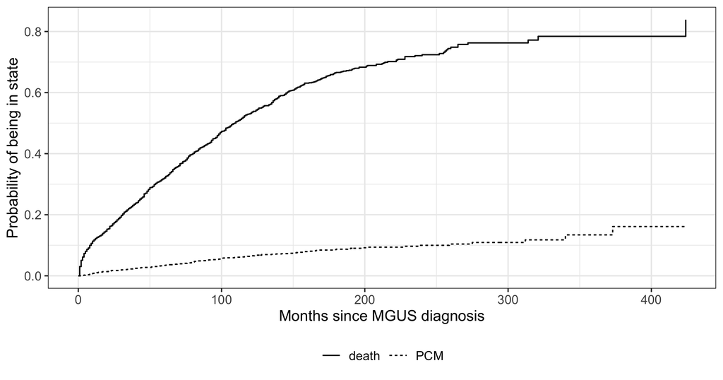

```r
survfit2(Surv(etime, ev) ~ 1, id = id, data = mg) |>
  ggcuminc(outcome = c("PCM", "death")) +
  labs(x = "Months since MGUS diagnosis", y = "Probability of being in state")
```

This is the first-transition view (competing risks, Lecture 13). A full illness-death analysis adds the transition PCM $\to$ death, uses start-stop data (`tmerge`) and one Cox model per transition. `mstate::` automates this; we only mention it.

# Practice

## In-class exercise

Dataset `cgd`. Work in pairs, 10 minutes.

1. Fit the AG model with `treat` and `sex`, with `cluster(id)`. Interpret the effect of `sex`.
2. Fit PWP (total time) with `strata(enum4)`. Does the treatment effect change? Why can it differ from AG?
3. For the question “does interferon reduce the *total number of infections* a patient has during one year?” which model do you recommend, and why?
4. Make an MCF plot by `sex`. What does the plot tell you that a HR does not?

## Quiz

1. Why is the model-based SE too small when events are treated as independent?
2. Which model has a common baseline hazard? Which stratifies by event number?
3. A patient is at risk for the 3rd event: when does the PWP risk set start?
4. What happens to the MCF if patients die early?

## Take-home messages

- Several events per subject: use **all** of them, but account for **correlation** (robust SE, `cluster(id)`)
- Data layout: one row per at-risk interval, `Surv(start, stop, event)`, `id`, event number
- **AG**: common baseline, overall rate; **PWP**: stratified by event number, conditional; **WLW**: marginal
- Choose by the **research question**, not by the p-value
- MCF = expected number of events per subject; use `survfit(..., id = id)`
- Death is a **competing/terminal** event: not ordinary censoring
- Multi-state models give a general language for transitions

**Next lecture:** other topics: frailty (with the conditional vs marginal contrast), interval censoring, sample size.

**Reading:** Collett, Chapter 13 (13.1 counting processes, 13.2 recurrent events: AG and PWP, 13.3 multiple events: WLW, 13.4 event history analysis). Seminar follows: bring your laptop.